# Analysis of Body Mass Index and Body Fat Percentage

This report is organized in the following order:-

1. Overview This section provides a general intoduction and describes the dataset and theory used behind it while concurrently explaining the features in this dataset.
2. Data Preparation This section covers the required data cleaning and data preparation steps.
3. Data Exploration This section explores dataset features and how they are related.
4. Statistical Modeling and Performance Evaluation This section first fits a complete multiple linear regression model. Then, we are performing a backward variable selection using the p-values to obtain a reduced model. After completing the above steps, we again perform another set of daignostic checks on the reduced model.
5. Summary and Conclusions This section provides a summary of the work, conclude our observations and discuss about the results.

# Introduction

The objective of this project is to find out the relationships between ‘Body Fat Percentage’ and the 'Body Mass Index' that we will be calculating during the analysis. This is a comprehensive dataset that lists the estimates of the percentage of body fat determined by underwater weighing and various body circumference measurements for 252 men. This dataset was taken from http://staff.pubhealth.ku.dk/~tag/Teaching/share/data/Bodyfat.html. It was generally supplied by Dr. A. Garth Fisher who gave the authorization to freely distribute the data.

# Overview

Some experts thought BMI(body mass index) as the most accurate and simple way to determine the effect of weight on your health. In fact, most recent medical research uses BMI as an indicator of someone’s health status and disease risk. Some debate about which values on the BMI scale the thresholds for ‘underweight’, ‘overweight’ and ‘obese’ should be set. However, the followings are used for the criteria. BMI < 18.5 : underweight, 18.5 < BMI < 25 : optimal weight, 25 < BMI < 30 : overweight, BMI > 30 : obese.

Although, in this project we will just be determining if a person is Obese or not which is given by :- BMI < 25 : Physically Fit BMI > 25 : Overweight

The main goal of the project will be to determine a relation between body fat and BMI and to conclude which is a better measure.

# Data Source

The dataset is being extracted from the above link providing just a single dataset named bodyfat.csv. the dataset contains 252 observations(a.k.a instances or records) and 15 decriptive(a.k.a independent) features(or attributes).

# Objective

The goal for this project is to find the relation between 'Body Fat Percentage' and other predictors as well as 'Body Mass Index' and others. We will be creating a new feature(variable) named BMI.

# Target Feature

Our target feature for this project will be 'BMI', which is calculated using the values of 'Weight' and 'Height' and is a continuous numerical feature, which further concludes that our project is on regression problem.

# Descriptive Features

The variable descriptions below are from bodyfat.csv file:

Density : Density determined from underwater weighing Fat : Percent body fat from Siri’s (1956) equation Age : Age (years) Weight : Weight (lbs) Height : Height (inches) Neck : Neck circumference (cm) Chest: Chest circumference (cm) Abdomen : Abdomen circumference (cm) Hip : Hip circumference (cm) Thigh : Thigh circumference (cm) Knee : Knee circumference (cm) Ankle : Ankle circumference (cm) Biceps : Biceps (extended) circumference (cm) Forearm : Forearm circumference (cm) Wrist : Wrist circumference (cm)

Also, we will be calculating a new variable, named: BMI : Body Mass Index which will be created as a ratio of Weight(it should be in kgs hence we will be converting it to kgs from lbs while performing the calculations) to Height(it should be in m hence we will be converting it to m from inches while performing the calculations) squared for the measure of Body Mass Index in addition to the above variables.

# Preliminaries

We would try to clean the dataset while taking into account the unusual values(such as negative vlue of age, weight etc), missing values, any categorical descriptive feature is encoded to be numeric, if the dataset has too many observations, we are supposed to work on a smaller random sample, though it is not the case for our dataset.

In the first step, let us import all the common modules we might be using for this project.

```python
# Importing modules
import numpy as np
import pandas as pd
import matplotlib.pyplot as plt
import seaborn as sns
import statsmodels.api as sm
import statsmodels.formula.api as smf
import patsy
import io
import warnings
import requests
import re
###
warnings.filterwarnings('ignore')
###
%matplotlib inline
%config InlineBackend.figure_format = 'retina'
plt.style.use("ggplot")
```

We will be reading the bodyfat dataset with the help of the given .csv file.

```python
c= pd.read_csv("Bodyfat.csv")
```

We will be specifying the attribute names and will read in the data before displaying the random 10 rows from the dataset.

```python
# SPECIFYING THE ATTRIBUTES NAME
attributeNames = [
'Density determined from underwater weighing',
'Percent body fat from Siris (1956) equation',
'Age (years)'
'Weight (lbs)',
'Height (inches)',
'Neck circumference (cm)',
'Chest circumference (cm)',
'Abdomen 2 circumference (cm)',
'Hip circumference (cm)',
'Thigh circumference (cm)',
'Knee circumference (cm)',
'Ankle circumference (cm)',
'Biceps (extended) circumference (cm)',
'Forearm circumference (cm)',
'Wrist circumference (cm)',
]

# READ IN DATA
url1 = pd.read_csv("Bodyfat.csv", sep = ',', names = attributeNames,header = None)

# DISPLAYING RANDOMLY SELECTED 10 ROWS
c.sample(10, random_state=999)
```

|  | Density | bodyfat | Age | Weight | Height | Neck | Chest | Abdomen | Hip | Thigh | Knee | Ankle | Biceps | Forearm | Wrist |
| --- | --- | --- | --- | --- | --- | --- | --- | --- | --- | --- | --- | --- | --- | --- | --- |
| 173 | 1.0603 | 16.9 | 36 | 176.25 | 71.50 | 38.7 | 98.2 | 90.3 | 99.9 | 59.2 | 37.7 | 21.5 | 32.4 | 28.4 | 17.8 |
| 73 | 1.0680 | 13.5 | 55 | 125.00 | 64.00 | 33.2 | 87.7 | 76.0 | 88.6 | 50.9 | 35.4 | 19.1 | 29.3 | 25.7 | 16.9 |
| 227 | 1.0418 | 25.2 | 55 | 198.50 | 74.25 | 38.3 | 105.3 | 96.7 | 106.6 | 64.0 | 42.6 | 23.4 | 33.2 | 30.0 | 18.4 |
| 20 | 1.0551 | 19.1 | 28 | 179.00 | 68.00 | 39.1 | 103.3 | 95.9 | 104.9 | 63.5 | 38.0 | 22.1 | 32.5 | 30.3 | 18.4 |
| 245 | 1.0641 | 15.2 | 68 | 155.50 | 69.25 | 36.3 | 97.4 | 84.3 | 94.4 | 54.3 | 37.5 | 22.6 | 29.2 | 27.3 | 18.5 |
| 7 | 1.0704 | 12.4 | 25 | 176.00 | 72.50 | 37.8 | 99.6 | 88.5 | 97.1 | 60.0 | 39.4 | 23.2 | 30.5 | 29.0 | 18.8 |
| 134 | 1.0435 | 24.4 | 41 | 168.25 | 69.50 | 36.5 | 98.4 | 87.2 | 98.4 | 56.0 | 36.9 | 23.0 | 34.0 | 29.8 | 18.1 |
| 26 | 1.0811 | 7.9 | 34 | 131.50 | 67.50 | 36.2 | 88.6 | 74.6 | 85.3 | 51.7 | 34.7 | 21.4 | 28.7 | 27.0 | 16.5 |
| 68 | 1.0847 | 6.3 | 54 | 155.25 | 69.25 | 37.5 | 89.3 | 78.4 | 96.1 | 56.0 | 37.4 | 22.4 | 32.6 | 28.1 | 18.1 |
| 40 | 1.0217 | 34.5 | 45 | 262.75 | 68.75 | 43.2 | 128.3 | 126.2 | 125.6 | 72.5 | 39.6 | 26.6 | 36.4 | 32.7 | 21.4 |

# DATA CLEANING AND THE TRANSFORMATION

We need to confirm that the feature types match the decription provided in the given documentation

```python
print(f"Shape of the dataset is {c.shape} \n")
print(f"Data types are below where 'object' indicates a string type: ")
print(c.dtypes)
```

```
Shape of the dataset is (252, 15)

Data types are below where 'object' indicates a string type:
Density    float64
bodyfat    float64
Age          int64
Weight     float64
Height     float64
Neck       float64
Chest      float64
Abdomen    float64
Hip        float64
Thigh      float64
Knee       float64
Ankle      float64
Biceps     float64
Forearm    float64
Wrist      float64
dtype: object
```

# CHECKING FOR MISSING VALUES

```python
print(f"Missing values are:")
print(c.isnull().sum())
```

```
Missing values are:
Density    0
bodyfat    0
Age        0
Weight     0
Height     0
Neck       0
Chest      0
Abdomen    0
Hip        0
Thigh      0
Knee       0
Ankle      0
Biceps     0
Forearm    0
Wrist      0
dtype: int64
```

In the given dataset, there are no attributes that contains any missing values.

# SUMMARY STATISTICS

We are providing the summary of continous features below

```python
from IPython.display import display, HTML
display(HTML('<b>Table 1: Summary of continuous features</b>'))
c.describe(include='int64')
```

**Table 1: Summary of continuous features**

|  | Age |
| --- | --- |
| count | 252.000000 |
| mean | 44.884921 |
| std | 12.602040 |
| min | 22.000000 |
| 25% | 35.750000 |
| 50% | 43.000000 |
| 75% | 54.000000 |
| max | 81.000000 |

```python
display(HTML('<b>Table 2: Summary of categorical features</b>'))
print("There are no categorical objects")
```

**Table 2: Summary of categorical features**

```
There are no categorical objects
```

As there're no categorical features, we have no summary to display.

```python
c.head()
```

|  | Density | bodyfat | Age | Weight | Height | Neck | Chest | Abdomen | Hip | Thigh | Knee | Ankle | Biceps | Forearm | Wrist |
| --- | --- | --- | --- | --- | --- | --- | --- | --- | --- | --- | --- | --- | --- | --- | --- |
| 0 | 1.0708 | 12.3 | 23 | 154.25 | 67.75 | 36.2 | 93.1 | 85.2 | 94.5 | 59.0 | 37.3 | 21.9 | 32.0 | 27.4 | 17.1 |
| 1 | 1.0853 | 6.1 | 22 | 173.25 | 72.25 | 38.5 | 93.6 | 83.0 | 98.7 | 58.7 | 37.3 | 23.4 | 30.5 | 28.9 | 18.2 |
| 2 | 1.0414 | 25.3 | 22 | 154.00 | 66.25 | 34.0 | 95.8 | 87.9 | 99.2 | 59.6 | 38.9 | 24.0 | 28.8 | 25.2 | 16.6 |
| 3 | 1.0751 | 10.4 | 26 | 184.75 | 72.25 | 37.4 | 101.8 | 86.4 | 101.2 | 60.1 | 37.3 | 22.8 | 32.4 | 29.4 | 18.2 |
| 4 | 1.0340 | 28.7 | 24 | 184.25 | 71.25 | 34.4 | 97.3 | 100.0 | 101.9 | 63.2 | 42.2 | 24.0 | 32.2 | 27.7 | 17.7 |

We are supposed to add a new attribute named, BMI (Body Mass Index) which can be calculated by using the given formula:-

BMI = (Weight*0.4535)/((Height*0.0254)^2) where, 1 lb = 0.4535 kgs and, 1 inch = 0.0254 m

```python
print("Adding a new BMI column using the given formula ((Weight*0.4535)/((Height*0.0254)^2))")
print("where 1lb = 0.4535 kgs and 1 inch = 0.0254 m")
c['BMI'] = ((c['Weight']*(0.4535))/(c['Height']*(0.0254))**2)
# DISPLAYS THE FIRST 5 ROWS
c.head()
```

```
Adding a new BMI column using the given formula ((Weight*0.4535)/((Height*0.0254)^2))
where 1lb = 0.4535 kgs and 1 inch = 0.0254 m
```

|  | Density | bodyfat | Age | Weight | Height | Neck | Chest | Abdomen | Hip | Thigh | Knee | Ankle | Biceps | Forearm | Wrist | BMI |
| --- | --- | --- | --- | --- | --- | --- | --- | --- | --- | --- | --- | --- | --- | --- | --- | --- |
| 0 | 1.0708 | 12.3 | 23 | 154.25 | 67.75 | 36.2 | 93.1 | 85.2 | 94.5 | 59.0 | 37.3 | 21.9 | 32.0 | 27.4 | 17.1 | 23.621987 |
| 1 | 1.0853 | 6.1 | 22 | 173.25 | 72.25 | 38.5 | 93.6 | 83.0 | 98.7 | 58.7 | 37.3 | 23.4 | 30.5 | 28.9 | 18.2 | 23.329606 |
| 2 | 1.0414 | 25.3 | 22 | 154.00 | 66.25 | 34.0 | 95.8 | 87.9 | 99.2 | 59.6 | 38.9 | 24.0 | 28.8 | 25.2 | 16.6 | 24.663733 |
| 3 | 1.0751 | 10.4 | 26 | 184.75 | 72.25 | 37.4 | 101.8 | 86.4 | 101.2 | 60.1 | 37.3 | 22.8 | 32.4 | 29.4 | 18.2 | 24.878180 |
| 4 | 1.0340 | 28.7 | 24 | 184.25 | 71.25 | 34.4 | 97.3 | 100.0 | 101.9 | 63.2 | 42.2 | 24.0 | 32.2 | 27.7 | 17.7 | 25.512183 |

We do not have any indpendent variable which is of no use, as all the features we have are continous and numerical and are required to do the calculations and 'BMI' is dependent on each one of them. (We do not having any variables like ID which are of no use in the regression model)

We do not have any columns that are required to be fixed neither do we have any categorical features to provie you with the unique values.

We will be checking if any of our 15 attributes and the other attribute that we created contains any missing values and if they do, we can remove them and fix the dataset. Though this is quite a tiring process but we will still carry it out.

```python
print("We are checking for the missing values in the given dataset for the independent variables")
print("The given dataset has no mising values")
mask = (c['Density']== "" ) | (c['bodyfat'] == "") | (c['Age'] == "") | (c['Weight'] == "") | (c['Height'] == "") | (c['Neck'] == "") | (c['Chest'] == "") | (c['Abdomen'] == "") | (c['Hip'] == "") | (c['Thigh'] == "") | (c['Knee'] == "") | (c['Ankle'] == "") | (c['Biceps'] == "") | (c['Forearm'] == "") | (c['Wrist'] == "") |  (c['BMI'] == "")
mask.value_counts(normalize = True)*100
# print("The given dataset has no mising values")
```

```
We are checking for the missing values in the given dataset for the independent variables
The given dataset has no mising values
```

```
False    100.0
dtype: float64
```

```python
print("Our depenent variable in the given project is the BMI value ")
```

```
Our depenent variable in the given project is the BMI value
```

We will be creating a new attribute named Result, which tells us if a given person has an BMI 0f less than 25 and greater than or equal to 25. If the perosn has he BMI less than 25, the person is considered fit and hence the 'Result' feature contains a 'true' value. Or if the value of BMI is greater than or equal to 25, the person is considered as overweight and hence the 'Result' feature contains a 'false' value.

```python
c['Result'] = c['BMI'] <=25
print("The Result here depicts if the person is Overweight or not")
print("Plotting the graphs for the two variables")
```

```
The Result here depicts if the person is Overweight or not
Plotting the graphs for the two variables
```

# Data Exploration

Our dataset can now be considered as "clean" and is ready for visualiation and statistical modeling.

# Univariate Visualisation

We will be plotting a bar chart for the attribute 'Result' which further determines if a person is overweight or not and is dependent on the value of BMI. This will help us in comparing between the two groups of people.

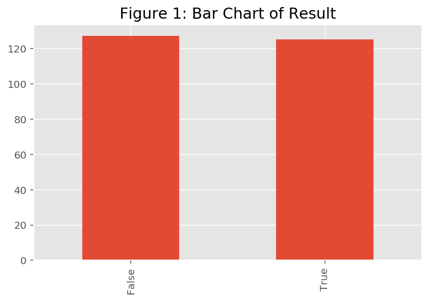

```python
plotgraph = c['Result'].value_counts().plot(kind = 'bar')
plotgraph.set_xticklabels(plotgraph.get_xticklabels(), rotation = 90)
plt.tight_layout()
plt.title('Figure 1: Bar Chart of Result', fontsize = 15)
plt.show();
```

[figure not shown]

```python
plotgraph = c['Age'].value_counts().plot(kind = 'bar')
plotgraph.set_xticklabels(plotgraph.get_xticklabels(), rotation = 30)
plt.tight_layout()
plt.title('Figure 2: Bar Chart for the Body Fat', fontsize = 15)
plt.show();

#  ax =c.plot.bar(x = 'Height', y = 'bodyfat', rot =0)
```

Let us plot a boxplot of bodyfat that tells us about its central value, and its variability.

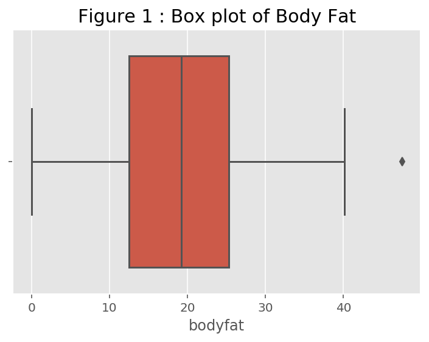

```python
sns.boxplot(c['bodyfat']).set_title('Figure 1 : Box plot of Body Fat', fontsize = 15)
plt.show();
```

And, we will be plotting a histogram of bodyfat which provides a visual interpretation of numerical data

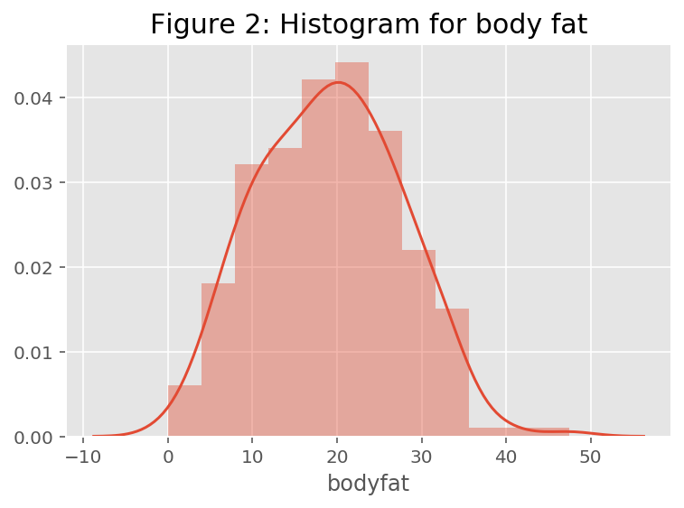

```python
sns.distplot(c['bodyfat'], kde = True).set_title("Figure 2: Histogram for body fat", fontsize = 15)
plt.show()
```